# A3: SPL Library Checkouts

### Introduction

The data that has been analyzed has been published by Seattle Public Libraries. It includes all checkouts made from 2022. In my analysis I explore various trends regarding specific authors, how many books are being checked out, and popular titles.

### Summary Information

After analyzing this data published by Seattle Public Libraries, I have found that the author with the most checkouts from a single title is Luis Alberto Urrea, with 2,950 checkouts from the book “The House of Broken Angels”. There are more digital checkouts than physical checkouts. The book with the most checkouts is “The House of Broken Angels”. The most popular material type checked out are books. January has the most book checkouts of all the months

### The Dataset

This dataset was published by the Seattle Public Library system. It includes data on all the checkouts from the library system in 2022. It includes whether or not the checkout was physical or digital, the material type, the publication year of the title, the month it was checked out, the author, the ISBN, and other information. Possible limitations of the data is that it may be slightly skewed towards titles that are checked out in masse, such as schools that have many students at once reading the same book for an assignment. This could lead people to fall conclusions about what are the most favored titles.

### First Trends Over Time Chart

This chart shows how many books were checked out per month. It seems like January is a popular month to start reading for many people. I included this chart because it gives some insight on when people are reading.

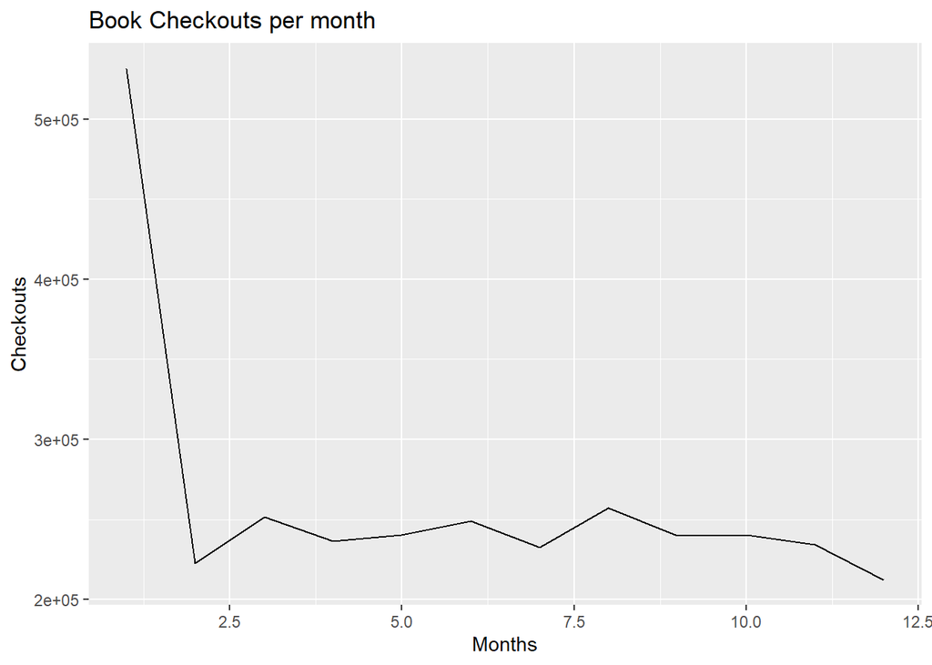

### Second Trends Over Time Chart

This second chart shows checkouts per month from books written by Trevor Noah. He seems to follow the same pattern as the general trend of when books are checked out, giving him January as his most popular month.

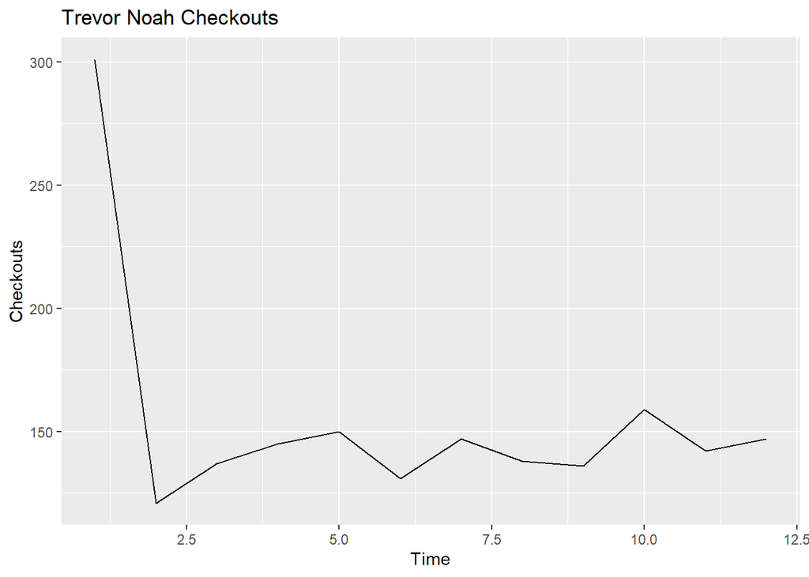

### My Choice

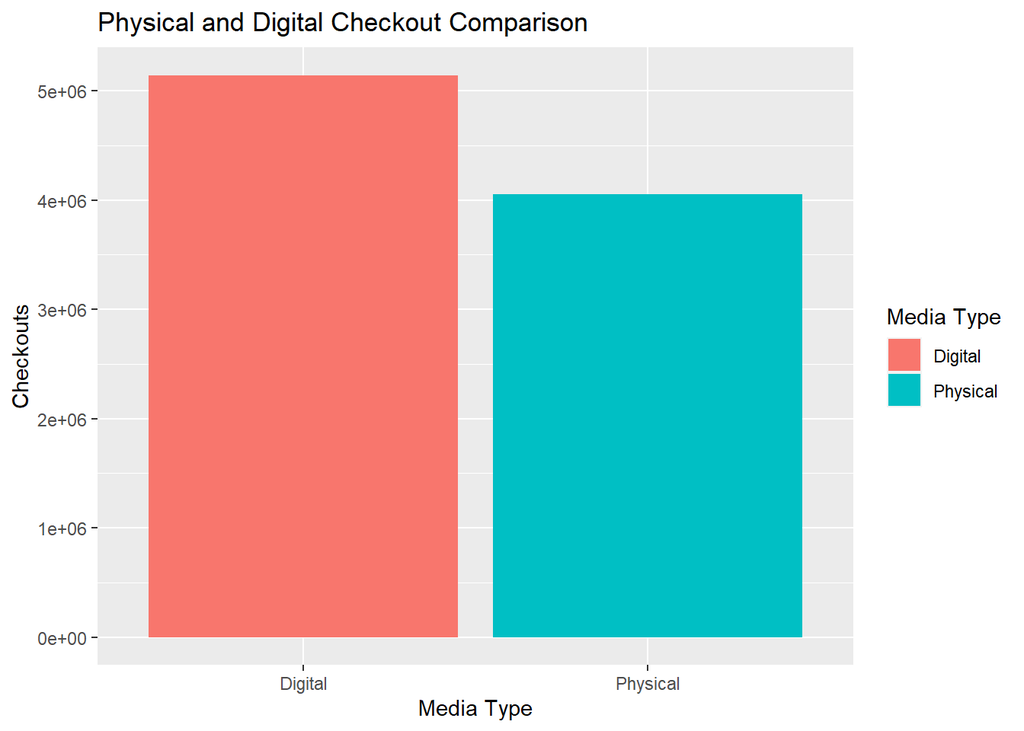